# Tutorial 8 - revised

Martyn Egan

16/11/2021

## Recap

Last week we looked at how to do multiple linear regression in R, including visualising our results to aid interpretation. In particular, we looked at the relationship between salary, grants and gender in the `salary` dataset.

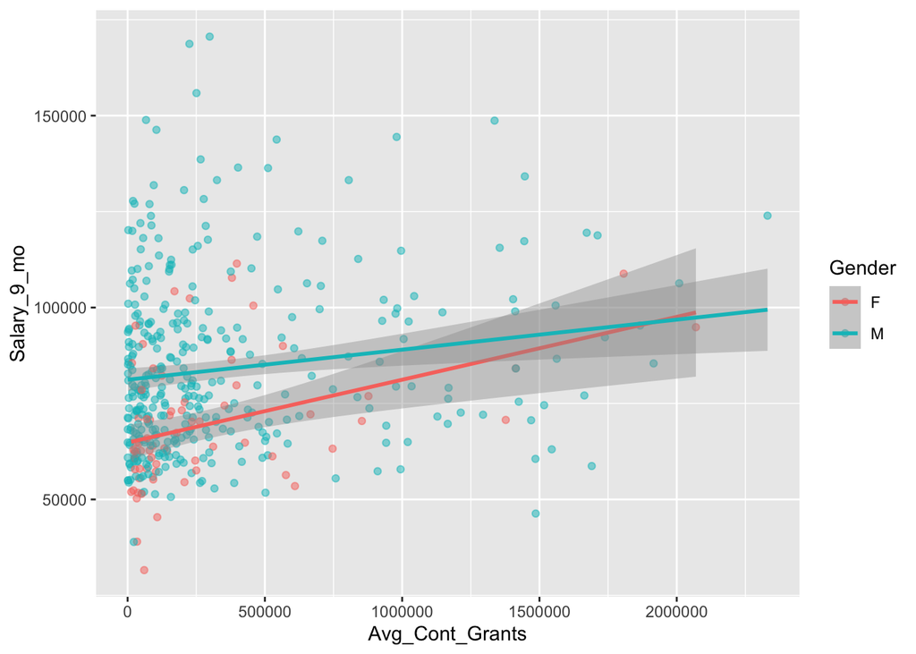

```r
ggplot(salary, aes(Avg_Cont_Grants, Salary_9_mo, group = Gender)) +
  geom_point(alpha = 0.5, aes(colour = Gender)) +
  geom_smooth(method = "lm", aes(colour = Gender))
```

This plot was an example of an interaction effect between a categorical (dummy) variable and a continuous variable. What about two categorical variables?

### Homework exercise

The homework exercise asked you to add pay grade to the mix.

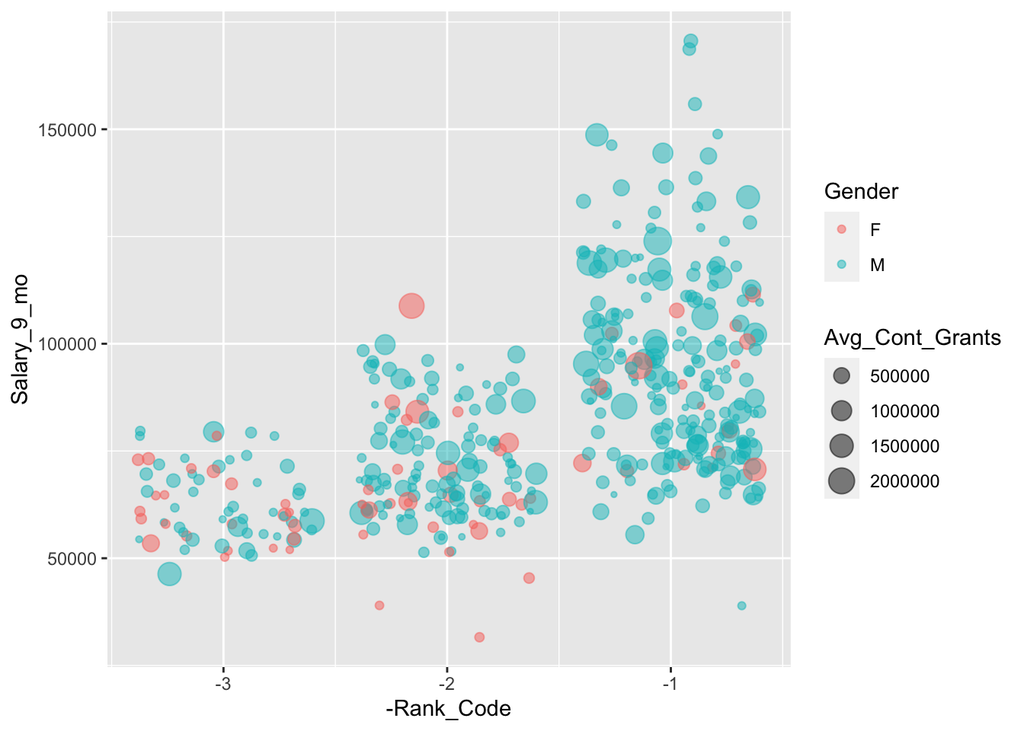

```r
ggplot(salary, aes(-Rank_Code, # we use "-" here because rank is in reverse order
                   Salary_9_mo,
                   colour = Gender,
                   size = Avg_Cont_Grants)) +
  geom_jitter(alpha = 0.5) #a good use case for jittering!
```

I think this is quite a powerful visualisation: how would you interpret it to an audience of policy makers?

Let’s make two regression models now: one with an additive relationship, another with a interaction effect between pay grade and gender. Try to think what kind of difference you would expect to see in visualising these two different models.

```r
# This is an additive model
mod1 <- lm(data = salary, Salary_9_mo ~ as.factor(Rank_Code) + Gender + Avg_Cont_Grants)

# This is an interaction model between two dummy vars
mod2 <- lm(data = salary, Salary_9_mo ~ as.factor(Rank_Code) * Gender + Avg_Cont_Grants)

stargazer(mod1, mod2, type = "html", title = "Regression Results")
```

**Regression Results**

|  | *Dependent variable:* |  |
| --- | --- | --- |
|  | Salary_9_mo |  |
|  | (1) | (2) |
| as.factor(Rank_Code)2 | -21,814.290*** | -21,943.110*** |
|  | (1,980.608) | (5,497.052) |
| as.factor(Rank_Code)3 | -29,240.530*** | -25,088.530*** |
|  | (2,580.651) | (5,750.892) |
| GenderM | 5,649.370** | 7,101.210 |
|  | (2,444.760) | (4,512.976) |
| Avg_Cont_Grants | 0.004** | 0.005** |
|  | (0.002) | (0.002) |
| as.factor(Rank_Code)2:GenderM |  | 406.903 |
|  |  | (5,889.130) |
| as.factor(Rank_Code)3:GenderM |  | -5,635.040 |
|  |  | (6,422.686) |
| Constant | 87,189.520*** | 85,805.120*** |
|  | (2,686.800) | (4,426.097) |
| Observations | 424 | 424 |
| R<sup>2</sup> | 0.368 | 0.369 |
| Adjusted R<sup>2</sup> | 0.362 | 0.360 |
| Residual Std. Error | 17,845.830 (df = 419) | 17,863.270 (df = 417) |
| F Statistic | 60.883*** (df = 4; 419) | 40.707*** (df = 6; 417) |
| *Note:* | p<0.1; p<0.05; p<0.01 |  |

Let’s have a look at the scatter plots:

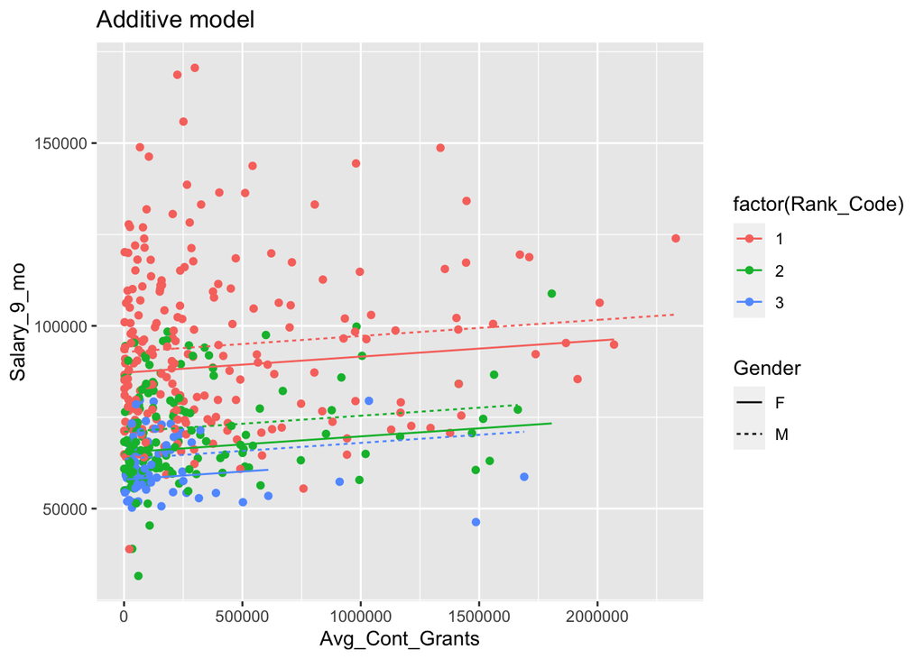

```r
mod1_aug <- augment(mod1)

ggplot(salary, aes(Avg_Cont_Grants, Salary_9_mo)) +
  geom_point(aes(colour = factor(Rank_Code))) +
  geom_line(data = mod1_aug, aes(y = .fitted,
                                      linetype = Gender,
                                      colour = `as.factor(Rank_Code)`)) +
  ggtitle("Additive model")
```

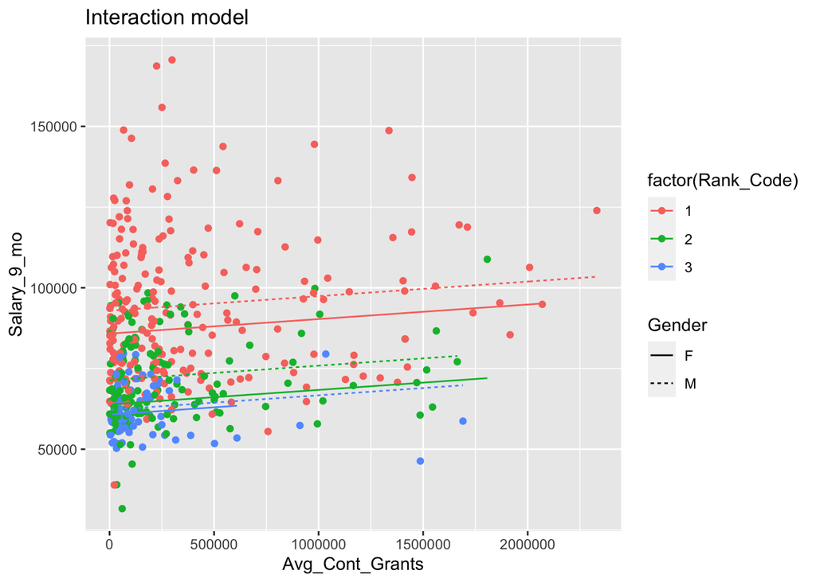

```r
mod2_aug <- augment(mod2)

ggplot(salary, aes(Avg_Cont_Grants, Salary_9_mo)) +
  geom_point(aes(colour = factor(Rank_Code))) +
  geom_line(data = mod2_aug, aes(y = .fitted,
                                      linetype = Gender,
                                      colour = `as.factor(Rank_Code)`)) +
  ggtitle("Interaction model")
```

```r
# Adding an interaction between grants and pay grade
mod3 <- lm(data = salary, Salary_9_mo ~ as.factor(Rank_Code) + Gender + Avg_Cont_Grants + as.factor(Rank_Code):Gender + as.factor(Rank_Code):Avg_Cont_Grants)

stargazer(mod1, mod2, mod3, type = "html", title = "Regression Results")
```

**Regression Results**

|  | *Dependent variable:* |  |  |
| --- | --- | --- | --- |
|  | Salary_9_mo |  |  |
|  | (1) | (2) | (3) |
| as.factor(Rank_Code)2 | -21,814.290*** | -21,943.110*** | -22,995.990*** |
|  | (1,980.608) | (5,497.052) | (5,753.098) |
| as.factor(Rank_Code)3 | -29,240.530*** | -25,088.530*** | -24,086.470*** |
|  | (2,580.651) | (5,750.892) | (5,890.910) |
| GenderM | 5,649.370** | 7,101.210 | 7,093.059 |
|  | (2,444.760) | (4,512.976) | (4,513.186) |
| Avg_Cont_Grants | 0.004** | 0.005** | 0.004* |
|  | (0.002) | (0.002) | (0.003) |
| as.factor(Rank_Code)2:GenderM |  | 406.903 | 534.041 |
|  |  | (5,889.130) | (5,891.951) |
| as.factor(Rank_Code)3:GenderM |  | -5,635.040 | -4,800.620 |
|  |  | (6,422.686) | (6,452.572) |
| as.factor(Rank_Code)2:Avg_Cont_Grants |  |  | 0.003 |
|  |  |  | (0.005) |
| as.factor(Rank_Code)3:Avg_Cont_Grants |  |  | -0.009 |
|  |  |  | (0.008) |
| Constant | 87,189.520*** | 85,805.120*** | 85,882.790*** |
|  | (2,686.800) | (4,426.097) | (4,477.353) |
| Observations | 424 | 424 | 424 |
| R<sup>2</sup> | 0.368 | 0.369 | 0.372 |
| Adjusted R<sup>2</sup> | 0.362 | 0.360 | 0.360 |
| Residual Std. Error | 17,845.830 (df = 419) | 17,863.270 (df = 417) | 17,861.880 (df = 415) |
| F Statistic | 60.883*** (df = 4; 419) | 40.707*** (df = 6; 417) | 30.793*** (df = 8; 415) |
| *Note:* | p<0.1; p<0.05; p<0.01 |  |  |

# Mini Project

Now that we know how to do multiple linear regression in R, we’re going to put our skills to the test. Let’s read in a completely new dataset:

```r
houses <- read.csv("https://raw.githubusercontent.com/gedeck/practical-statistics-for-data-scientists/master/data/house_sales.csv", sep = "\t")
```

We’re going to spend the rest of class on a mini project. The `houses` dataset is adapted from the King County (Seattle) tax assessors database, available in the “Practical Statistics for Data Scientists” (O’Reilly) book. It contains prices for 22687 houses, alongside a series of additional variables including size of property, the year the property was built, etc. We want to use house price (AdjSalePrice) as our outcome variable, and to find a number of predictor variables that are significantly associated with house price.

We have 4 tasks in our workflow: explore our dataset; generate some hypotheses; test these hypotheses with a regression; and interpret the outcome of that regression.

## EDA

```r
# summary stats

# visualisations
```

## Regression

```r
#model 1

#model 2

#model 3
```